# Traverse Survey

The purposed of this lab is to how to use data collected using Total Station (distance and angles) for closed-traverse calculation.

ECIV 340L, CEE, UofSC true  
09-17-2021

RELATED RESOUCES:

- [**LECTURE SLIDES**](https://emailsc-my.sharepoint.com/:p:/g/personal/ahmedf_email_sc_edu/Ecq9kTGOKjhCmLX-jLbrgC4B3VAX3U_jYcYWHtZI9YLsmA?e=5KMzFL)
- [**LEVEL BOOK**](https://emailsc-my.sharepoint.com/:b:/g/personal/ahmedf_email_sc_edu/ESyiKQnHnZVCqqfCTH8MAJoBwobAMCcLoEvl_7Kj3aNHZA?e=OxD4TD)
- [**FIELD BOOK**](https://emailsc-my.sharepoint.com/:b:/g/personal/ahmedf_email_sc_edu/EbY8KWP9bDdAhe9G0sqjULYB6jo5q9xZEoQJAWC4ErwGMw?e=MgWRvZ)
- **DATA FORM**
- [**LAB PROCEDURE (FIELD)**](https://emailsc-my.sharepoint.com/:w:/g/personal/ahmedf_email_sc_edu/EVhCUbSfnWZEuw5jzqpEwx0BgZGKl2RUWMNWfOixIfjSVg?e=mb6Yfr)
- [**DEMO CALCULATION**](https://emailsc-my.sharepoint.com/:x:/g/personal/ahmedf_email_sc_edu/EbG-dtwaahJBlDruoU9YqYcBQLic9ABFzimrbOqZ_Vn0dw?e=5telqW)

# TRAVERSING

A traverse is a series of consecutive lines whose ends have been marked in the field and whose lengths and directions have been determined from observations. In traditional surveying by ground methods, traversing, the act of marking the lines, that is, establishing traverse stations and making the necessary observations, is one of the most basic and widely practiced means of determining the relative locations of points. There are two kinds of traverses: closed and open. Two categories of closed traverses exist: polygon and link. In the polygon traverse, as shown in Fig. 1(a), the lines return to the starting point, thus forming a closed figure that is both geometrically and mathematically closed. Link traverses finish upon another station that should have a positional accuracy equal to or greater than that of the starting point. The link type (geometrically open, mathematically closed), as illustrated in Fig. 1(b), must have a closing reference direction. Closed traverses provide checks on the observed angles and distances, which is an extremely important consideration. They are used extensively in control, construction, property, and topographic surveys.

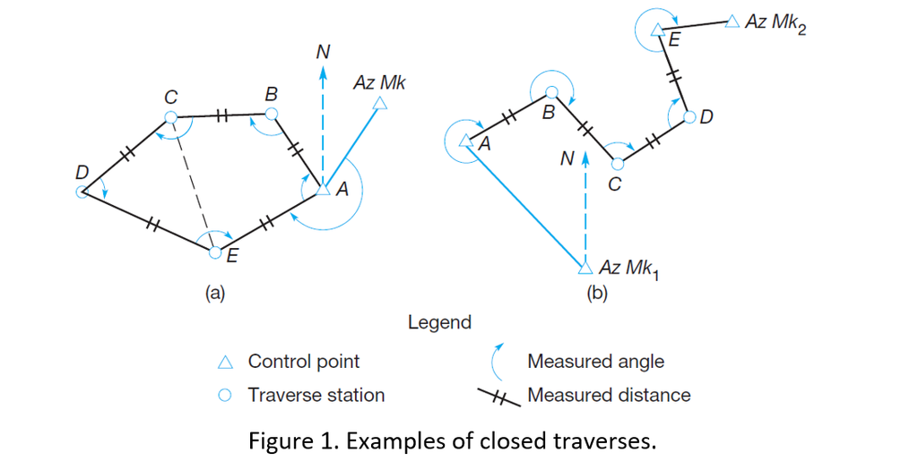

An open traverse (geometrically and mathematically open) (Fig. 2) consists of a series of lines that are connected but do not return to the starting point or close upon a point of equal or greater order accuracy. Open traverses should be avoided because they offer no means of checking for observational errors and mistakes.

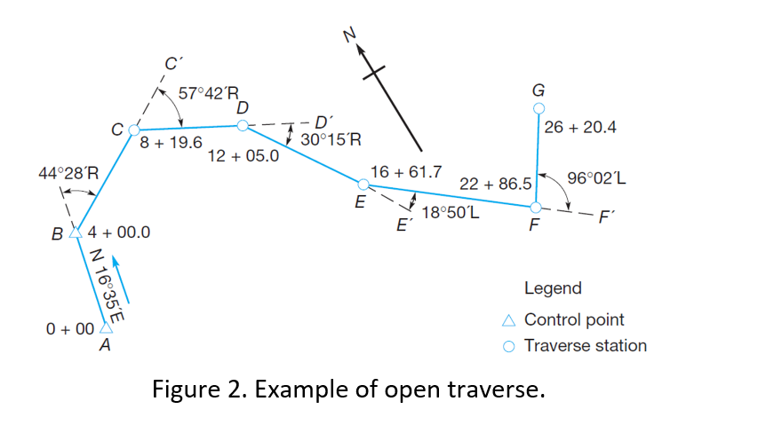

**Azimuths:** Azimuths are horizontal angles observed clockwise from any reference meridian. Azimuths have also been more generally defined as a horizontal angle measured clockwise from any fixed reference plane or easily established base direction line.

**Bearings:** Bearings are another system for designating directions of lines. The bearing of a line is defined as the acute horizontal angle between a reference meridian and the line. The angle is observed from either the north or south toward the east or west, to give a reading smaller than 90°. The letter N or S preceding the angle, and E or W following it shows the proper quadrant. Thus, a properly expressed bearing includes quadrant letters and an angular value. An example is N80°E.

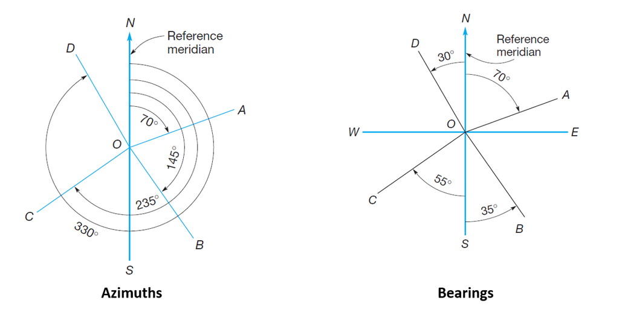

**Observations of Traverse Angles:** The methods used in observing angles or directions of traverse lines vary and include:  
(1) interior angles,  
(2) angles to the right,  
(3) deflection angles, and  
(4) azimuths.

**Traversing by Interior Angles:** Interior-angle traverses are used for many types of work, but they are especially convenient for property surveys. Although interior angles could be observed either clockwise or counterclockwise, to reduce mistakes in reading, recording, and computing, they should always be turned clockwise from the Backsight station to the Foresight station. The procedure is illustrated in Fig. 1(a). Angle EAB of Fig. 1(a) was observed at station A, with the Backsight on station E and the foresight at station B.

**Selection of Traverse Stations:** Positions selected for setting traverse stations vary with the type of survey. In general, guidelines to consider in choosing them include accuracy, utility, and efficiency. Of course, intervisibility between adjacent stations, forward and back, must be maintained for angle and distance observations. The stations should also ideally be set in convenient locations that allow for easy access. Ordinarily, stations are placed to create lines that are as long as possible. This not only increases efficiency by reducing the number of instrument setups, but it also increases accuracy in angle observations.

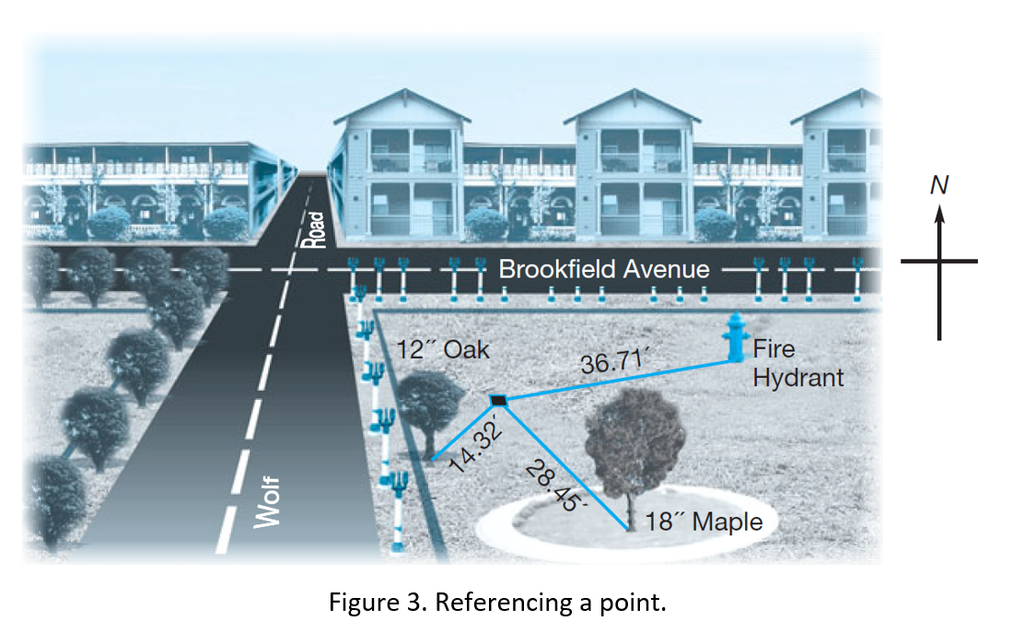

## Departures and Latitudes

The departure of a course is its orthographic projection on the east-west axis of the survey and is equal to the length of the course multiplied by the sine of its azimuth angle. Departures are sometimes called eastings or westings.

The latitude of a course is its orthographic projection on the north-south axis of the survey, and is equal to the course length multiplied by the cosine of its azimuth angle. Latitude is also called northing or southing.

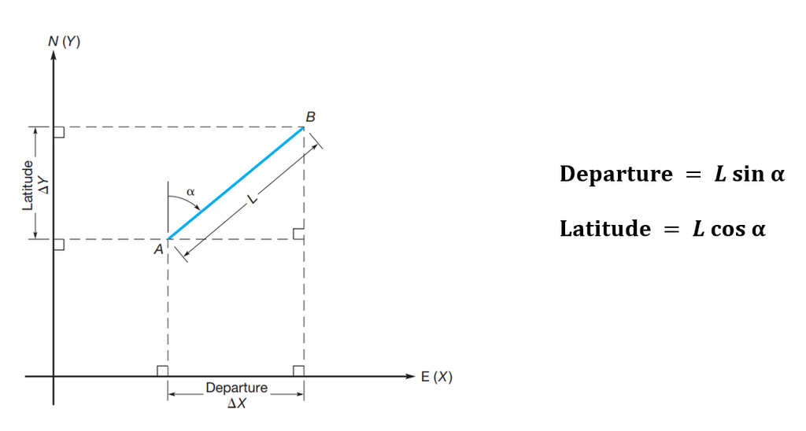

## Traverse Adjustment

For any closed traverse, the linear misclosure must be adjusted (or distributed) throughout the traverse to “close” or “balance” the figure. This is true even though the misclosure is negligible in plotting the traverse at map scale. There are several elementary methods available for traverse adjustment, but the one most commonly used is the compass rule (Bowditch method).

**Compass (Bowditch) Rule** The compass, or Bowditch, rule adjusts the departures and latitudes of traverse courses in proportion to their lengths. Corrections by this method are made according to the following rules:

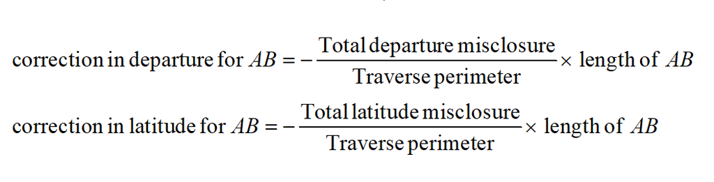

## Traversing with a Total Station (Example)

For the traverse ABCDE, the observed interior angles are given in the table below. The fixed azimuth of line AW is 234°17’18" and the measured angle to the right for EAW is 208°7’36". It is known that the coordinate of point A is 10,000 Easting and 5,000 Northing. Calculate the coordinates of point B, C, D, and E. Additionally, determine the linear misclosure and precision.

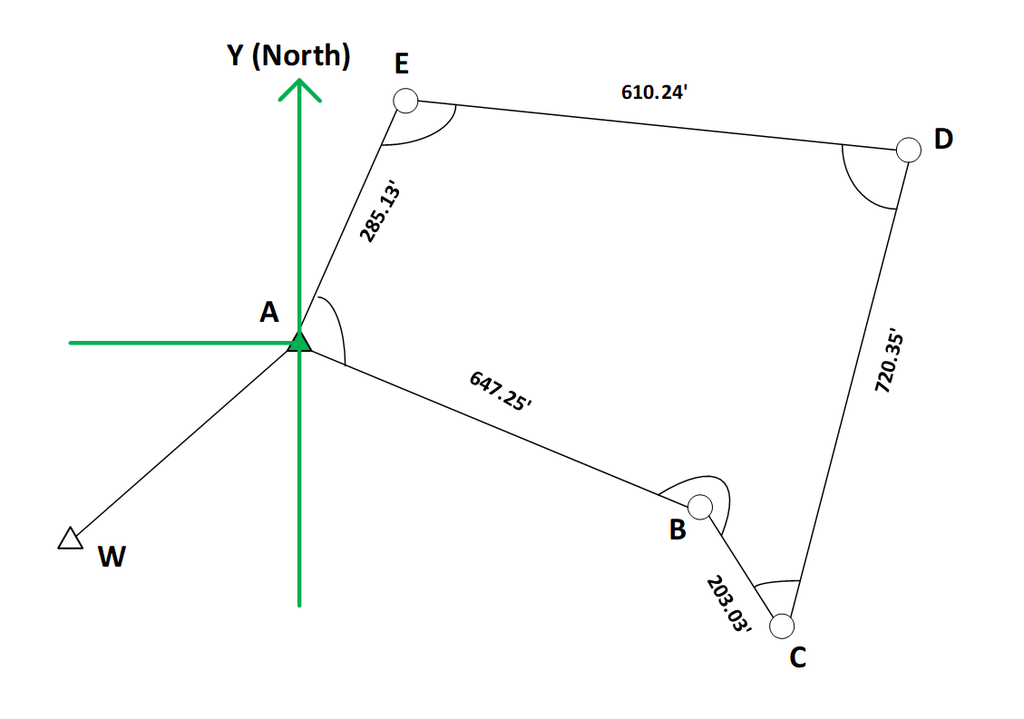

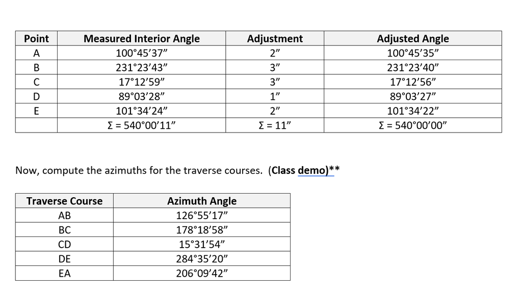

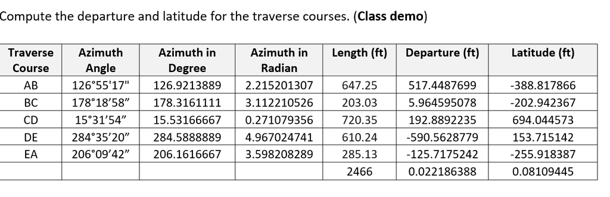

**Error of Closure:*** If the measured bearings and distances are plotted on a sheet of paper, the figure will not close because of error in latitudes (E_L) and error in departures (E_D).

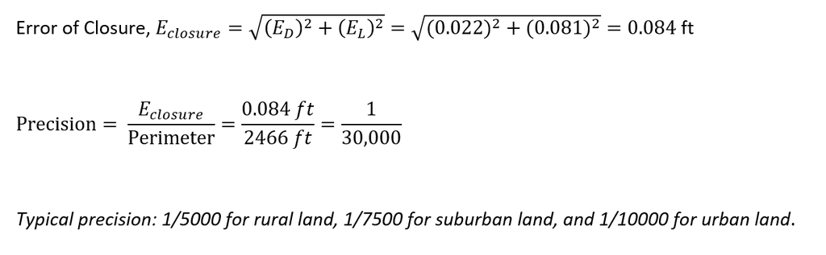

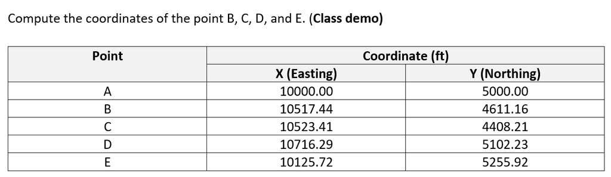

## Lab Task: Traversing

The purpose of this task is to set a traverse with five stations (A, B, C, D, and E) as presented in previous section using interior angles to determine the angles between traverse lines. Additionally, compute the coordinates of the points of the traverse.  
**Known Information:**  
1. The fixed azimuth of line AW is 234°17’18".  
2. The coordinate of point A is X = 5,000 Easting and Y = 7,500 Northing.